# COVE Analysis Exercise: Member Call Transcript Review

**Author:** Zara Z

Here is my plan for this analysis:

1. Clean the data and address as many data quality issues as possible
2. Export a manual-review file for items that do not pass quality checks and cannot be included in the model
3. Use exploratory data analysis (EDA) to identify the themes in the dataset
4. Check those themes against the kinds of problems UnitedHealthcare's own COVE team has publicly said it watches for based on article I found
5. Score each call's sentiment using a model built for conversational text, and corroborate it with a second, independent piece of text for each call.
6. Dig into the primary finding(s)
7. Summarize findings and recommendations

## 1. Setup

This notebook was created in Google Colab. If you plan on running it yourself, you'll need to upload `COVE Analysis Exercise.xlsx` when prompted (code chunk #4). I've also added as many comments and notes along the way to explain my thought process and selections

```python
# Openpyxl is a small library for reading and writing Excel files
# Transformers is needed for the sentiment model in Section 6

!pip install -q openpyxl transformers --upgrade
```

```
   ━━━━━━━━━━━━━━━━━━━━━━━━━━━━━━━━━━━━━━━━ 11.7/11.7 MB 63.2 MB/s eta 0:00:00
```

```python
import re
import io
import json
import numpy as np
import pandas as pd
import matplotlib.pyplot as plt
from sklearn.feature_extraction.text import TfidfVectorizer, ENGLISH_STOP_WORDS
from sklearn.cluster import KMeans
from sklearn.metrics import silhouette_score
from scipy import stats
import openpyxl
from openpyxl.styles import Font, PatternFill, Alignment
```

```python
# Parameters used throughout this analysis are collected here

CONFIG = {
    # Column names from the raw export
    "text_column": "Long Transcript",
    "summary_column": "Call-intent auto summarization",
    "sentiment_column": "Call Sent",
    "category_column": "ACC-1",
    "date_column": "Call date",
    "lob_column": "LOB",
    "state_column": "Mem State",

    # Words to ignore when building themes, on top of standard English stop words like "the" and "and"
    "custom_stopwords": {
        "united", "healthcare", "health", "care", "calling", "call", "thank",
        "thanks", "hello", "hi", "good", "morning", "afternoon", "evening",
        "name", "speaking", "pleasure", "today", "yes", "no", "okay", "ok",
        "um", "uh", "advocate", "adv", "caller", "xxxx", "xxxxx", "member",
        "just", "going", "know", "like", "right", "got", "let", "sure",
        "moment", "second", "minute", "verify", "verifying", "verified",
        "automated", "system", "recorded", "quality", "training", "purposes",
        "redacted", "phone", "dob", "ssn", "memberid",
        # Added after reviewing top terms per cluster
        "umm", "mhm", "alright", "said", "told", "did", "didn", "want",
        "think", "remember", "make", "help", "called", "new", "day", "time",
        "week", "ll", "ve", "re", "don", "isn", "won", "maybe",
        "hmm", "mm", "yeah", "ma", "ago", "probably", "correct", "trying",
        "believe", "regarding", "directly", "great", "sounds", "come", "went",
        "say", "says", "saying", "mean", "getting", "sorry", "thing", "doing",
        "tell", "really", "ahead", "able", "appreciate", "guess", "gave", "way",
        "guys", "supposed", "check", "huh", "fine", "talk", "talked", "bye",
        "wanted", "kind", "actually", "gonna", "look", "does", "having",
        "needed", "needs", "somebody", "understand", "stuff", "hear", "little",
        "contact", "using", "reason", "far", "lot", "took", "birth", "id",
        "haven", "people","god", "honey", "nice", "wonderful", "perfect", "definitely",
        "exactly", "figure", "spoke", "wondering", "mmm", "righty", "telling", "ask",
    },

    # Only searching group counts between 8 and 11. Below 8, distinct problems started blending into
    # one group, for example wheelchairs and medication ending up together. Above 11, groups
    # started fragmenting into pieces too thin to reliably read, some with only 2 calls in them
    "k_range": range(8, 12),
    "random_state": 42,

    # Which emotion labels from the sentiment model count as "frustrated" for this analysis
    "frustration_labels": {"anger", "annoyance", "disapproval", "disappointment", "disgust", "confusion"},

    # Sentiment model settings
    "chunk_size_words": 70,   # Maximum number of words per chunk sent to model
    "batch_size": 16,         # Number of chunks scored together in a single pass (for efficiency)
}
```

```python
# Load the file using Colab's upload widget if available, or a local file otherwise
try:
    from google.colab import files
    print("Upload 'COVE Analysis Exercise.xlsx' now:")
    uploaded = files.upload()
    SRC = list(uploaded.keys())[0]
except ImportError:
    SRC = "COVE Analysis Exercise.xlsx" # Make sure file name matches this
    print(f"Not running in Colab. Looking for a local file named '{SRC}'.")

print("Using file:", SRC)
```

```
Upload 'COVE Analysis Exercise.xlsx' now:
```

Upload widget is only available when the cell has been executed in the current browser session. Please rerun this cell to enable.

```
Saving COVE Analysis Exercise.xlsx to COVE Analysis Exercise.xlsx
Using file: COVE Analysis Exercise.xlsx
```

## 2. Data cleaning

1. **2 rows with no transcripts at all.** These are summary-only rows. Rather than dropping them, I think it's safe to fall back to a shorter auto-generated summary of the call for those two rows, so we're keeping as much as possible of the data for a more complete analysis.
2. **Unprotected personal information in the transcript text.** A handful of transcripts still show a phone number, date of birth, or name, even though the structured `Mem First` and `Mem Last` columns had already been anonymized. I will redact this information below, we should not need them. Also, HIPAA? I could be wrong, please correct me if so :)

```python
def load_raw(path):
    wb = openpyxl.load_workbook(path, data_only=True)
    ws = wb["Sheet1"]                              # The data lives on a sheet named "Sheet1"
    headers = [c.value for c in ws[1]][:15]         # Export has 15 columns
    rows = [[ws.cell(row=r, column=c).value for c in range(1, 16)] for r in range(2, ws.max_row + 1)]
    df = pd.DataFrame(rows, columns=headers)
    df.insert(0, "row_num", range(2, 2 + len(df)))  # Keeps the original Excel row num for traceability
    return df

raw = load_raw(SRC)
print("Raw shape:", raw.shape)
raw.head(3)
```

```
Raw shape: (100, 16)
```

|  | row_num | Call date | Call-intent auto summarization | Long Transcript | Call Sent | Mem First | Mem Last | Mem State | Contract | LOB | UCID | CPL Flag | Skill | ACC-1 | ACC-2 | ACC-Con |
| --- | --- | --- | --- | --- | --- | --- | --- | --- | --- | --- | --- | --- | --- | --- | --- | --- |
| 0 | 2 | 2026-05-01 | "The caller is seeking clarification regarding... | "Adv: Good afternoon. Thanks for calling Unite... | -5.1 | Patient_01_First | Patient_01_Last | VA | HXXXX-XXX-XXX | DSNP | 00066044391777660322 | Y | VQ_UHC_GovtOps_CareCoordination_DSNP_MR_BIE | INCOMPLETE CALL DATA | INCOMPLETE CALL DATA | INCOMPLETE CALL DATA |
| 1 | 3 | 2026-05-01 | "The caller inquired about returning unused ox... | "Adv: Hi, thank you so much for calling United... | 0.2 | Patient_02_First | Patient_02_Last | TN | HXXXX-XXX-XXX | M&R | 00066461851777645769 | Y | VQ_UHC_GovtOps_Service_MedAdvCSM_Offshore_OGA | BENEFITS | BENEFITS COVERAGE BREAKDOWN | BENEFITS DME OR SUPPLIES COVERED |
| 2 | 4 | 2026-05-01 | "The caller inquired whether the insurance pla... | "Caller: She ever come back here?\nAdv: Hello,... | -0.2 | Patient_03_First | Patient_03_Last | NC | HXXXX-XXX-XXX | M&R | 00098059921777638673 | N | VQ_UHC_GovtOps_Service_MedAdv_Offshore_Tier1_IBEX | BENEFITS | ESTIMATION OF OOP COST | BENEFITS DME OR SUPPLIES COVERED |

```python
# Count duplicate rows only if they have matching transcript text. This guards
# against pandas treating two blank transcripts as equal to each other.
text_col = CONFIG["text_column"]
has_text = raw[text_col].notna() & (raw[text_col].astype(str).str.strip() != "")
dupe_mask = has_text & raw.duplicated(subset=[text_col], keep="first")

print("True duplicate rows found:", raw.loc[dupe_mask, "row_num"].tolist() or "None.")
df = raw.loc[~dupe_mask].reset_index(drop=True)
print("Shape after removing duplicates:", df.shape)

df["has_transcript"] = df[text_col].notna() & (df[text_col].astype(str).str.strip() != "")
print("Rows with no transcript text, summary-only:", df.loc[~df["has_transcript"], "row_num"].tolist())
```

```
True duplicate rows found: None.
Shape after removing duplicates: (100, 16)
Rows with no transcript text, summary-only: [88, 97]
```

### Redacting personal information

I am working off of the assumption that Personal Health Information (PHI) should not appear in text that gets analyzed. I will be using pattern matching, known as regular expressions or regex, to find and remove phone numbers, dates of birth, SSNs, and member ID numbers from the transcript text. I did not attempt to remove full names, since regex cannot reliably tell a person's name apart from an ordinary word; that requires a more sophisticated language tool than I am using here. I did find at least two name mentions while scanning through transcripts, and I am noting that limitation here rather than claiming this redaction step caught everything.

```python
# Regex for phone numbers, dates of birth, SSNs, and member ID numbers
PHONE_RE = re.compile(r'\b(?:1[-.\s]?)?\(?\d{3}\)?[-.\s]\d{3}[-.\s]\d{4}\b')   # For example, 555-123-4567
DOB_RE = re.compile(r'\b(0[1-9]|1[0-2])[/-](0[1-9]|[12]\d|3[01])[/-](19|20)\d{2}\b')  # For example, 11/23/1954
SSN_RE = re.compile(r'\b\d{3}-\d{2}-\d{4}\b')                                        # For example, 123-45-6789
MEMBERID_RE = re.compile(r'\bmember (?:id|ID)(?: number)?\s*(?:is\s*)?\d{6,12}\b', re.IGNORECASE)  # Member ID

def redact_phi(text):
    if not isinstance(text, str):
        return text
    text = SSN_RE.sub("[REDACTED-SSN]", text)
    text = DOB_RE.sub("[REDACTED-DOB]", text)
    text = PHONE_RE.sub("[REDACTED-PHONE]", text)
    text = MEMBERID_RE.sub("[REDACTED-MEMBERID]", text)
    return text

summary_col = CONFIG["summary_column"]
for col in [summary_col, text_col]:
    df[col] = df[col].fillna("").astype(str).str.strip().str.strip('"')  # Handling stray quotes

df["transcript_redacted"] = df[text_col].apply(redact_phi)
df["summary_redacted"] = df[summary_col].apply(redact_phi)
df["analysis_text"] = df["transcript_redacted"].where(df["has_transcript"], df["summary_redacted"])
df["phi_found"] = df[text_col] != df["transcript_redacted"]

print(f"Personal information redacted in {df['phi_found'].sum()} of {len(df)} rows:", df.loc[df["phi_found"], "row_num"].tolist())

# Sanity check on one row
example = df[df["row_num"] == 12].iloc[0]
before_sents = re.split(r'(?<=[.\n])', example[text_col])
after_sents = re.split(r'(?<=[.\n])', example["transcript_redacted"])
print("\nRow 12, sentences where redaction changed the text:\n")
for b, a in zip(before_sents, after_sents):
    if b != a:
        print("BEFORE:", b.strip())
        print("AFTER :", a.strip())
        print()
```

```
Personal information redacted in 11 of 100 rows: [12, 30, 34, 43, 48, 54, 59, 64, 84, 94, 101]

Row 12, sentences where redaction changed the text:

BEFORE: Adv: 11/23/1954.
AFTER : Adv: [REDACTED-DOB].

BEFORE: I have two phone numbers, so I'm going to give you the mobile phone number that I have on file, 909-269-5193.
AFTER : I have two phone numbers, so I'm going to give you the mobile phone number that I have on file, [REDACTED-PHONE].

BEFORE: Adv: Mary B as in boy Louis 11/23/1954 is Earth.
AFTER : Adv: Mary B as in boy Louis [REDACTED-DOB] is Earth.
```

Works great! Moving on..

### The existing category tags are incomplete

```python
cat_col = CONFIG["category_column"]
untagged_mask = df[cat_col].isna() | df[cat_col].isin(["INCOMPLETE CALL DATA", "NEXIDIA TRANSCRIPT UNAVAILABLE"]) | (df[cat_col] == "")
n_untagged = int(untagged_mask.sum())
n_tagged = len(df) - n_untagged

print(f"{n_tagged}/{len(df)} calls, or {n_tagged/len(df)*100:.0f}%, have a usable {cat_col} tag. "
      f"{n_untagged} calls, or {n_untagged/len(df)*100:.0f}%, do not.")
```

```
78/100 calls, or 78%, have a usable ACC-1 tag. 22 calls, or 22%, do not.
```

```python
# Checking whether ACC-2 or ACC-Con ever rescue a call that ACC-1 leaves untagged, since all three
# are tag columns but the check above only looked at ACC-1
tag_cols = ["ACC-1", "ACC-2", "ACC-Con"]
placeholder_vals = ["INCOMPLETE CALL DATA", "NEXIDIA TRANSCRIPT UNAVAILABLE"]

all_null_together = (df["ACC-1"].isna() == df["ACC-2"].isna()).all() and (df["ACC-1"].isna() == df["ACC-Con"].isna()).all()
print(f"ACC-1, ACC-2, and ACC-Con are missing on exactly the same rows: {all_null_together}.")

rescue_mask = untagged_mask & df["ACC-2"].notna() & ~df["ACC-2"].isin(placeholder_vals)
print(f"Calls untagged by ACC-1 where ACC-2 has a real value ACC-1 doesn't: {rescue_mask.sum()}.")

plan_leak_mask = df["ACC-Con"].astype(str).str.contains(r"Medicare Advantage|\(HMO|\(PPO", regex=True, na=False)
print(f"Rows where ACC-Con actually holds what looks like a plan name instead of a tag: {plan_leak_mask.sum()}.")
df.loc[plan_leak_mask, ["row_num", "ACC-1", "ACC-2", "ACC-Con"]]
```

```
ACC-1, ACC-2, and ACC-Con are missing on exactly the same rows: True.
Calls untagged by ACC-1 where ACC-2 has a real value ACC-1 doesn't: 0.
Rows where ACC-Con actually holds what looks like a plan name instead of a tag: 3.
```

|  | row_num | ACC-1 | ACC-2 | ACC-Con |
| --- | --- | --- | --- | --- |
| 66 | 68 | INCOMPLETE CALL DATA | INCOMPLETE CALL DATA | AARP Medicare Advantage from UHC NC-0021 (HMO-... |
| 82 | 84 | RX REFILL DENIED | RX OVERRIDE REQUEST | AARP Medicare Advantage from UHC IN-0006 (PPO) |
| 83 | 85 | BENEFITS COVERAGE BREAKDOWN | BENEFITS DME OR SUPPLIES COVERED | AARP Medicare Advantage Essentials from UHC IN... |

ACC-1, ACC-2, and ACC-Con turn out to be a three-level hierarchy, a broad category, a sub-category, and a specific reason, that gets filled in together or not at all, rather than three independent tagging attempts. They are missing on the exact same rows every time, so combining them does not shrink the 22% gap from the previous check, a call either has all three levels or none of them.

What combining them does give me is a fuller label for the calls that are already tagged, for example "BENEFITS" alone becomes "BENEFITS > BENEFITS COVERAGE BREAKDOWN > BENEFITS DME OR SUPPLIES COVERED." I built that combined field below.

```python
# ACC-1, ACC-2, and ACC-Con combined into one fuller label for calls that have them
df["category_full"] = df[tag_cols].apply(lambda r: " > ".join(r.dropna()), axis=1)
df["category_full"] = df["category_full"].where(df["category_full"] != "", "Untagged")

df.loc[~untagged_mask, "category_full"].value_counts().head(10)
```

| category_full | count |
| --- | --- |
| BENEFITS > BENEFITS COVERAGE BREAKDOWN > BENEFITS DME OR SUPPLIES COVERED | 11 |
| TRANSPORTATION > TRANSPORTATION CHANGE OR SCHEDULE OR CANCEL TRIP > INFO GIVEN OR ISSUE RESOLVED | 8 |
| BENEFITS > ESTIMATION OF OOP COST > BENEFITS DME OR SUPPLIES COVERED | 6 |
| RX INQUIRY > RX REFILL DENIED > RX OVERRIDE REQUEST | 5 |
| RX INQUIRY > RX COVERAGE DETERMINATION > RX NOT COVERED | 3 |
| PROVIDER SEARCH > FIND A PROVIDER NEAR ME > DME | 3 |
| CLAIMS INQUIRY > UNDERSTANDING PATIENT RESPONSIBILITY OR EOB > COPAY OR COINSURANCE OR DEDUCTIBLE | 2 |
| PRIOR AUTH INQUIRY > PRIOR AUTH STATUS CHECK > PRIOR AUTH NOT RECEIVED | 2 |
| RX INQUIRY > RX PRIOR AUTH > RX AUTH NOT OBTAINED OR NOT REQUIRED | 2 |
| CLAIMS INQUIRY > WHY WAS MY CLAIM DENIED OR PARTIALLY DENIED > CLAIM NO COVERAGE AT TIME OF SERVICE | 2 |

**dtype:** int64

```python
# Adding the same placeholder exclusion used above, since a call tagged "INCOMPLETE CALL DATA" in
# ACC-1 still joins into a non-empty category_full string and would otherwise slip through as tagged
df.loc[df["ACC-1"].isin(placeholder_vals), "category_full"] = "Untagged"

untagged_mask_combined = df["category_full"] == "Untagged"
n_untagged_combined = int(untagged_mask_combined.sum())
n_tagged_combined = len(df) - n_untagged_combined

print(f"Using ACC-1, ACC-2, and ACC-Con combined instead: {n_tagged_combined}/{len(df)} calls, or "
      f"{n_tagged_combined/len(df)*100:.0f}%, have a usable tag. {n_untagged_combined} calls, or "
      f"{n_untagged_combined/len(df)*100:.0f}%, still do not.")
```

```
Using ACC-1, ACC-2, and ACC-Con combined instead: 78/100 calls, or 78%, have a usable tag. 22 calls, or 22%, still do not.
```

This gap is still large enough for me to not completely trust the category tag alone. This is why I will be identifying themes independently instead.

## 3. Manual review workbook

I exported every row I touched or flagged into its own tab in a separate Excel file: the transcripts with no text, the redacted PHI shown before and after, and every call the platform left uncategorized. Anything unusual is in this file for an analyst to check by hand as needed.

```python
HEADER_FILL = PatternFill(start_color="2A78D6", end_color="2A78D6", fill_type="solid")
HEADER_FONT = Font(bold=True, color="FFFFFF")
WRAP = Alignment(wrap_text=True, vertical="top")

def _write_sheet(wb, name, sheet_df, col_widths=None, wrap_cols=None):
    # Writes a dataframe into a new sheet with a blue header row and wrapped text where it is needed
    ws = wb.create_sheet(name)
    ws.append(list(sheet_df.columns))
    for cell in ws[1]:
        cell.fill = HEADER_FILL
        cell.font = HEADER_FONT
    for row in sheet_df.itertuples(index=False):
        ws.append(list(row))
    wrap_cols = wrap_cols or set()
    col_widths = col_widths or {}
    for i, col in enumerate(sheet_df.columns, start=1):
        letter = ws.cell(row=1, column=i).column_letter
        ws.column_dimensions[letter].width = col_widths.get(col, 18)
        if col in wrap_cols:
            for cell in ws[letter][1:]:
                cell.alignment = WRAP
    ws.freeze_panes = "A2"   # Keeps the header row visible while scrolling
    return ws

wb_out = openpyxl.Workbook()
wb_out.remove(wb_out.active)   # Removes the default empty sheet

# README tab
ws = wb_out.create_sheet("README")
ws.column_dimensions["A"].width = 100
readme_lines = [
    "COVE Analysis Exercise: Data Quality and Manual Review Log", "",
    "Every row the cleaning process modified or flagged, for independent review.","",
    "Sheets: Missing_Transcript, PHI_Redacted, Untagged_Or_Incomplete.",
]
for i, line in enumerate(readme_lines, start=1):
    cell = ws.cell(row=i, column=1, value=line)
    if i == 1:
        cell.font = Font(bold=True, size=13)
    cell.alignment = Alignment(wrap_text=True, vertical="top")

# Rows with no transcript
df_missing = df.loc[~df["has_transcript"],
                     ["row_num", "UCID", CONFIG["date_column"], CONFIG["state_column"], CONFIG["lob_column"],
                      CONFIG["summary_column"], "ACC-1", "ACC-2", "ACC-Con"]].copy()
_write_sheet(wb_out, "Missing_Transcript", df_missing,
             col_widths={CONFIG["summary_column"]: 70}, wrap_cols={CONFIG["summary_column"]})

# Redacted rows, showing the original text next to the redacted text
df_phi = df.loc[df["phi_found"], ["row_num", "UCID", CONFIG["date_column"], CONFIG["state_column"]]].copy()
df_phi["Original transcript"] = df.loc[df["phi_found"], text_col]
df_phi["Redacted transcript"] = df.loc[df["phi_found"], "transcript_redacted"]
_write_sheet(wb_out, "PHI_Redacted", df_phi,
             col_widths={"Original transcript": 70, "Redacted transcript": 70},
             wrap_cols={"Original transcript", "Redacted transcript"})

# Calls the platform left uncategorized
df_untagged = df.loc[untagged_mask,
                      ["row_num", "UCID", CONFIG["date_column"], CONFIG["state_column"], CONFIG["lob_column"],
                       CONFIG["summary_column"], "ACC-1", "ACC-2", "ACC-Con"]].copy()
_write_sheet(wb_out, "Untagged_Or_Incomplete", df_untagged,
             col_widths={CONFIG["summary_column"]: 70}, wrap_cols={CONFIG["summary_column"]})

EXPORT_PATH = "COVE_Data_Quality_Review.xlsx"
wb_out.save(EXPORT_PATH)
print("Wrote", EXPORT_PATH)

# Downloads the file automatically in Colab, otherwise it stays in the working directory
try:
    from google.colab import files as colab_files
    colab_files.download(EXPORT_PATH)
except ImportError:
    pass
```

```
Wrote COVE_Data_Quality_Review.xlsx
```

## 4. Exploratory data analysis: finding themes in the calls

Exploratory data analysis (EDA) means systematically looking at what is actually in the data before drawing conclusions from it. Here, that means figuring out what members are really calling about, rather than trusting category tags alone, since the previous section showed that 22% of calls do not have one.

To do this, I used two standard text-analysis techniques. The first, called TF-IDF, converts each call's text into a set of numbers that highlight the words that matter most in that call, while ignoring common words that appear everywhere. The second, called K-Means, is a method for automatically grouping/ clustering similar calls together based on those numbers, without me telling it what the groups should be in advance. I only look at the caller's own words for this step, not the advocate's language, since phrases like "thank you for calling" would swamp every cluster.

K-Means needs to be told how many groups to look for. I tried a range of group counts and picked the one with the best silhouette score, which is a standard measure of how cleanly separated the resulting groups are from each other. A higher silhouette score means the groups are more distinct, which is better.

```python
def extract_caller_lines(transcript):
    # Pulls out just the caller's lines from a transcript formatted with "Adv:" and "Caller:" labels
    if not isinstance(transcript, str) or "Caller:" not in transcript:
        return transcript   # No "Adv:"/"Caller:" labels here, for example on summary-only rows. Return what is there.

    lines = transcript.split("\n")
    caller_lines = [l.split("Caller:", 1)[1].strip() for l in lines if "Caller:" in l]
    return " ".join(caller_lines)

df["caller_text"] = df.apply(
    lambda r: extract_caller_lines(r[text_col]) if r["has_transcript"] else r["analysis_text"],
    axis=1,
)

# In case the extraction above came back empty for some row, fall back to whatever text is available
empty = df["caller_text"].str.strip() == ""
df.loc[empty, "caller_text"] = df.loc[empty, "analysis_text"]
```

```python
# Two extra cleanup passes on the caller's words specifically, on top of the stopword list.
# Appointment times and dates ("11", "30", "2nd") are call-specific, so they'll get
# stripped rather than treated as topic words. Speech disfluencies transcribed literally ("tried
# tried", "mm hmm") get collapsed, since they would otherwise look like meaningful two word phrases.
df["caller_text"] = df["caller_text"].str.replace(r"\b\d+(st|nd|rd|th)?\b", "", regex=True)
df["caller_text"] = df["caller_text"].str.replace(r"\b(\w+)[,\s]+\1\b", r"\1", regex=True, flags=re.IGNORECASE)

STOPWORDS = list(CONFIG["custom_stopwords"].union(ENGLISH_STOP_WORDS))

vectorizer = TfidfVectorizer(
    max_df=0.6,               # Ignores words that show up in over 60% of calls
    min_df=2,                 # Ignores words that only appear once across the whole sample
    stop_words=STOPWORDS,
    ngram_range=(1, 2),       # Looks at single words and two word phrases, so it can catch terms like "prior authorization", for example
)
X = vectorizer.fit_transform(df["caller_text"])

# Tries a handful of group counts, within the range explained in CONFIG above, and keeps
# whichever one has the best silhouette score, which again, means they're more distinct
scores = {}
models = {}
for k in CONFIG["k_range"]:
    km = KMeans(n_clusters=k, random_state=CONFIG["random_state"], n_init=10)
    labels = km.fit_predict(X)
    scores[k] = silhouette_score(X, labels)
    models[k] = (km, labels)

best_k = max(scores, key=scores.get)
best_model, best_labels = models[best_k]
df["theme_cluster"] = best_labels

print("Silhouette score by number of clusters:", {k: round(v, 3) for k, v in scores.items()})
print(f"\nChosen number of clusters: {best_k}, with a silhouette score of {scores[best_k]:.3f}.")
```

```
Silhouette score by number of clusters: {8: np.float64(0.011), 9: np.float64(0.01), 10: np.float64(0.016), 11: np.float64(0.014)}

Chosen number of clusters: 10, with a silhouette score of 0.016.
```

These silhouette scores are fairly low. I went through three rounds of reviewing the actual top terms per group and adding conversational filler, transcription artifacts, and interjections to the stopword list; I also stripped call-specific numbers (times, dates) and collapsed literal word repeats from the transcript before vectorizing. I am treating this grouping as a starting point to set themes.

```python
# The words that define each cluster
terms = np.array(vectorizer.get_feature_names_out())
print("Top terms per group:\n")
for c in range(best_k):
    center = best_model.cluster_centers_[c]
    top_idx = center.argsort()[::-1][:12]   # The 12 words that weigh most heavily in this group
    n = (df["theme_cluster"] == c).sum()
    print(f"Group {c} (n={n}): {', '.join(terms[top_idx])}")
```

```
Top terms per group:

Group 0 (n=3): insulin, diabetes, pre, authorization, pump, medication, message, husband, error, prior authorization, pre authorization, prior
Group 1 (n=15): medication, doctor, pharmacy, card, pcp, plus, form, plan, address, nebulizer, prescription, holding
Group 2 (n=4): catheters, smaller, carry, urinary, catheter, charges, submitted, medicine, stephanie, shouldn, denied, rock
Group 3 (n=14): chair, home, lift, lift chair, doctor, prior, covered, wheelchair, therapy, physical therapy, physical, authorization
Group 4 (n=15): synapse, machine, supplies, cpap, mask, order, company, synops, problem, send, sent, doctor
Group 5 (n=13): pay, scooter, equipment, companies, doctor, mobility, walker, nebulizer, miss, breathe, company, money
Group 6 (n=6): maria, line, representative, authorized representative, authorized, safe, cinco, fully, better, home, apria, nurse behalf
Group 7 (n=12): oxygen, portable, synapse, portable oxygen, order, refill, linda, paying, link, insurance, use, problems
Group 8 (n=13): ride, transportation, dialysis, wheelchair, schedule, walker, wednesday, appointment, june, medical, pick, appointments
Group 9 (n=5): discount, city, billing, insurance, prescription, wouldn, insurance company, coverage, company, billing insurance, accept insurance, drug
```

### Naming the groups

I read a sample of transcripts from each group above and assigned each one a plain-language theme name based on what those calls were actually about. A few of the raw groups above turned out to be two angles on the same underlying issue, for example diabetes-supply prior authorizations and lift-chair prior authorizations, so I rolled those into one shared theme name.

```python
# Business-friendly theme name for each cluster, assigned by hand; a few clusters share a label
# since they turned out to be two angles on the same underlying issue
THEME_ROLLUP = {
    0: "Prior authorization & equipment approval",
    1: "Pharmacy / medication access",
    2: "Billing & coverage denials",
    3: "Prior authorization & equipment approval",
    4: "Oxygen / equipment vendor & delivery failures",
    5: "Mobility equipment billing & claims",
    6: "Authorized representative calls",
    7: "Oxygen / equipment vendor & delivery failures",
    8: "Transportation scheduling",
    9: "Billing & coverage denials",
}
df["theme_label"] = df["theme_cluster"].map(THEME_ROLLUP).fillna("Other / unclustered")

theme_counts = df["theme_label"].value_counts()
theme_counts
```

| theme_label | count |
| --- | --- |
| Oxygen / equipment vendor & delivery failures | 27 |
| Prior authorization & equipment approval | 17 |
| Pharmacy / medication access | 15 |
| Transportation scheduling | 13 |
| Mobility equipment billing & claims | 13 |
| Billing & coverage denials | 9 |
| Authorized representative calls | 6 |

**dtype:** int64

## 5. Checking against COVE's own "watch list"

UnitedHealthcare has spoken publicly about the COVE team this analysis is for, so I checked my themes against what the team itself says it watches for.

> Christopher Snowbeck, ["UnitedHealthcare's mission control targets customer woes to build its brand,"](https://www.startribune.com/unitedhealthcares-mission-control-targets-customer-woes-to-build-its-brand/601789616) *Star Tribune*, April 2026. Also syndicated via [InsuranceNewsNet](https://insurancenewsnet.com/oarticle/unitedhealthcares-mission-control-targets-customer-woes-to-build-its-brand).

The article names five categories the team watches for: call transfers, digital or online portal confusion, tone signals in speech, medical equipment supplier transition confusion, and external factors outside the company's control. I checked each one against this sample, including the supplier category:

```python
# Keyword searches used to check each watch-list category below
txt = df[text_col].str.lower().fillna("")

# Each *_mask below is True for a call if its text matches that category's keywords, used
# to filter df row-by-row in the table below
transfer_mask = txt.str.contains(r'\btransfer', regex=True, na=False)
digital_mask = txt.str.contains(r'\b(?:website|portal|log ?in|the app|online account)\b', regex=True, na=False)
weather_mask = txt.str.contains(r'\b(?:weather|storm|hurricane|snow|flood|blizzard)\b', regex=True, na=False)
medicare_mask = df[CONFIG["lob_column"]] == "M&R"   # M&R is short for Medicare & Retirement, one of two Medicare plan types in this sample
supplier_mask = txt.str.contains(r'\b(?:supplier|vendor)\b', regex=True, na=False)

checks = pd.DataFrame({
    "watch-list category": [
        "Call transfer friction",
        "Digital / self-service confusion",
        "External / environmental factors",
        "Medicare (M&R) vs. other plan type, sentiment gap",
        "Any supplier or vendor mention, generic keyword",
    ],
    "calls matched": [transfer_mask.sum(), digital_mask.sum(), weather_mask.sum(),
                       medicare_mask.sum(), supplier_mask.sum()],
    "mean Call Sent, matched": [
        round(df.loc[transfer_mask, CONFIG["sentiment_column"]].mean(), 2),
        round(df.loc[digital_mask, CONFIG["sentiment_column"]].mean(), 2),
        round(df.loc[weather_mask, CONFIG["sentiment_column"]].mean(), 2) if weather_mask.sum() else "n/a",
        round(df.loc[medicare_mask, CONFIG["sentiment_column"]].mean(), 2),
        round(df.loc[supplier_mask, CONFIG["sentiment_column"]].mean(), 2),
    ],
    "mean Call Sent, rest of sample": [
        round(df.loc[~transfer_mask, CONFIG["sentiment_column"]].mean(), 2),
        round(df.loc[~digital_mask, CONFIG["sentiment_column"]].mean(), 2),
        round(df.loc[~weather_mask, CONFIG["sentiment_column"]].mean(), 2) if weather_mask.sum() else "n/a",
        round(df.loc[~medicare_mask, CONFIG["sentiment_column"]].mean(), 2),
        round(df.loc[~supplier_mask, CONFIG["sentiment_column"]].mean(), 2),
    ],
})
checks
```

|  | watch-list category | calls matched | mean Call Sent, matched | mean Call Sent, rest of sample |
| --- | --- | --- | --- | --- |
| 0 | Call transfer friction | 24 | 0.82 | -0.04 |
| 1 | Digital / self-service confusion | 24 | 0.80 | -0.03 |
| 2 | External / environmental factors | 6 | 0.97 | 0.12 |
| 3 | Medicare (M&R) vs. other plan type, sentiment gap | 67 | 0.03 | 0.46 |
| 4 | Any supplier or vendor mention, generic keyword | 36 | 0.59 | -0.07 |

Transfers and digital or portal mentions do not read as pain points here; if anything, they skew notably positive. Calls mentioning a transfer average +0.82 versus -0.04 for the rest of the sample (n=24), and calls mentioning the website, portal, or app average +0.80 versus -0.03 (n=24). Medicare (M&R) sentiment runs lower than the other plan type in this sample (0.03 versus 0.46, n=67), loosely matching the article, though this sample is too small to lean on that alone. Weather mentions are too rare to draw a conclusion from (n=6).

The supplier or vendor row is the interesting one, and not in the direction I expected, since Section 4's clustering had already surfaced issues in the "Oxygen / equipment vendor & delivery failures" theme. Calls that simply mention a supplier or a vendor actually skew positive, not negative (+0.59 versus -0.07 for the rest of the sample, n=36). Most of those 36 calls are ordinary "let's get you set up with an equipment supplier" conversations that resolve without issue; mentioning a supplier is not itself a problem. A generic keyword search cannot tell that apart from transition confusion, so instead of stopping here, I went ahead and tested something more specific in Section 7: does one particular, named vendor correlate with worse sentiment?

## 6. Sentiment scoring

For each call, I scored how frustrated the caller sounds using a model called SamLowe/roberta-base-go_emotions. This is a version of a language model called RoBERTa. This version is particularly built using Reddit data and has 28 labels, so it is built for more conversational text rather than formal writing. It scores text against a set of emotion labels including anger, annoyance, disapproval, disappointment, disgust, and confusion, which maps directly onto the kind of frustration signals I am looking for in these calls.

Each call is broken into chunks of about 70 words at a time, since the model can only process a limited amount of text at once. I use the highest frustration score across a call's chunks, rather than the average, since a few polite words near the end of a call should not cancel out a complaint earlier in the same call.

I score two independent pieces of text for each call: the transcript itself, and a separate, shorter auto-generated summary of the call that the platform already provides in a different field. If both independently show the same pattern, that is stronger evidence the frustration signal is true, and not just an artifact of how I processed one particular piece of text.

```python
# This step downloads model weights the first time it runs and can take a few minutes; please be patient :)
!pip install -q --upgrade transformers

from transformers import pipeline
import torch

device = 0 if torch.cuda.is_available() else -1   # Uses GPU because we can only be so patient
emotion_clf = pipeline(
    "text-classification",
    model="SamLowe/roberta-base-go_emotions",
    top_k=None,        # Leave as None so it returns a score for every label
    truncation=True,
    device=device,
)

FRUSTRATION_LABELS = CONFIG["frustration_labels"]
CHUNK_SIZE = CONFIG["chunk_size_words"]

def make_chunks(text, chunk_size_words=CHUNK_SIZE):
    # Breaks a piece of text into chunks small enough for the model to process at once; the size itself comes from CONFIG above
    if not isinstance(text, str) or not text.strip():
        return []
    words = text.split()
    return [" ".join(words[i:i + chunk_size_words]) for i in range(0, len(words), chunk_size_words)] or [text]

df["_transcript_chunks"] = df["caller_text"].apply(make_chunks)
df["_summary_chunks"] = df["summary_redacted"].apply(make_chunks)

# Combines every chunk, from both text sources and every call, into one list, so the model can
# score them together in batches. This is for efficiency. Will matter more with larger datasets.
flat_chunks, chunk_owner, chunk_source = [], [], []
for idx, chunks in df["_transcript_chunks"].items():
    flat_chunks.extend(chunks)
    chunk_owner.extend([idx] * len(chunks))
    chunk_source.extend(["transcript"] * len(chunks))
for idx, chunks in df["_summary_chunks"].items():
    flat_chunks.extend(chunks)
    chunk_owner.extend([idx] * len(chunks))
    chunk_source.extend(["summary"] * len(chunks))

all_preds = emotion_clf(flat_chunks, batch_size=CONFIG["batch_size"], truncation=True)
chunk_frustration = [sum(p["score"] for p in preds if p["label"] in FRUSTRATION_LABELS) for preds in all_preds]

scores_df = pd.DataFrame({"row": chunk_owner, "source": chunk_source, "score": chunk_frustration})
frustration_by_row = scores_df.loc[scores_df["source"] == "transcript"].groupby("row")["score"].max()
summary_frustration_by_row = scores_df.loc[scores_df["source"] == "summary"].groupby("row")["score"].max()

df["frustration_score"] = df.index.map(frustration_by_row).fillna(0.0)
df["summary_frustration_score"] = df.index.map(summary_frustration_by_row).fillna(0.0)
df.drop(columns=["_transcript_chunks", "_summary_chunks"], inplace=True)

pearson_fr = (-df["frustration_score"]).corr(df[CONFIG["sentiment_column"]])
spearman_fr = (-df["frustration_score"]).corr(df[CONFIG["sentiment_column"]], method="spearman")
print(f"Transcript-based frustration score vs. the platform's own {CONFIG['sentiment_column']} score: "
      f"Pearson correlation={pearson_fr:.3f}, Spearman correlation={spearman_fr:.3f}.")
print("Pearson and Spearman are both standard ways to measure how closely two numbers move together,")
print("on a scale from -1 to 1. Spearman only looks at rank order, so it is less thrown off by outliers.")

agreement = df["frustration_score"].corr(df["summary_frustration_score"])
print(f"\nAgreement between the transcript-based score and the summary-based score: correlation={agreement:.3f}.")
print("A meaningful positive correlation here means two independent pieces of text agree on which")
print("calls sound frustrated, which is stronger evidence than relying on the transcript alone.")
```

```
Transcript-based frustration score vs. the platform's own Call Sent score: Pearson correlation=0.170, Spearman correlation=0.170.
Pearson and Spearman are both standard ways to measure how closely two numbers move together,
on a scale from -1 to 1. Spearman only looks at rank order, so it is less thrown off by outliers.

Agreement between the transcript-based score and the summary-based score: correlation=0.456.
A meaningful positive correlation here means two independent pieces of text agree on which
calls sound frustrated, which is stronger evidence than relying on the transcript alone.
```

```python
# Which themes carry the most frustration signal
frustration_by_theme = df.groupby("theme_label")["frustration_score"].mean().sort_values(ascending=False)
sentiment_by_theme_check = df.groupby("theme_label")[CONFIG["sentiment_column"]].mean().sort_values()

print("Mean frustration score by theme, higher means more frustration signal detected:")
print(frustration_by_theme)
print("\nMean platform Call Sent score by theme, lower means worse, shown here for reference:")
print(sentiment_by_theme_check)
```

```
Mean frustration score by theme, higher means more frustration signal detected:
theme_label
Oxygen / equipment vendor & delivery failures    0.690658
Prior authorization & equipment approval         0.673042
Pharmacy / medication access                     0.642242
Mobility equipment billing & claims              0.566572
Billing & coverage denials                       0.478060
Transportation scheduling                        0.430242
Authorized representative calls                  0.320251
Name: frustration_score, dtype: float64

Mean platform Call Sent score by theme, lower means worse, shown here for reference:
theme_label
Oxygen / equipment vendor & delivery failures   -0.821852
Authorized representative calls                 -0.620000
Billing & coverage denials                       0.098889
Transportation scheduling                        0.584615
Prior authorization & equipment approval         0.602353
Pharmacy / medication access                     0.812667
Mobility equipment billing & claims              0.853846
Name: Call Sent, dtype: float64
```

## 7. The primary finding: the "Synapse" vendor

While reading through the clustered transcripts in Section 4, one thing kept coming up: callers naming a specific medical equipment supplier, "Synapse". This was worth testing properly.

One wrinkle worth noting: the transcription engine spells this vendor's name a few different ways across calls. "Synapse," "Snaps," "Cnaps," and "Caps" all show up in context for what is clearly the same vendor; one row uses three different spellings in a single sentence. The count below only searches for "synapse," so it is a conservative floor on how many calls actually involve this vendor.

```python
sent_col = CONFIG["sentiment_column"]
mentions_synapse = df[text_col].str.lower().str.contains("synapse", na=False)
syn_mean = df.loc[mentions_synapse, sent_col].mean()
other_mean = df.loc[~mentions_synapse, sent_col].mean()

t_stat, p_val = stats.ttest_ind(
    df.loc[mentions_synapse, sent_col].dropna(),
    df.loc[~mentions_synapse, sent_col].dropna(),
    equal_var=False,   # This is Welch's t-test, which does not assume the two groups have equal variance
)

print(f"Calls mentioning 'Synapse': {mentions_synapse.sum()} out of {len(df)}, or {mentions_synapse.mean()*100:.0f}%.")
print(f"Mean Call Sent score, Synapse calls: {syn_mean:.2f}. All other calls: {other_mean:.2f}.")
print(f"Welch's t-test result: t={t_stat:.2f}, p={p_val:.4f}.")
print("A t-test checks whether two groups are actually different, not just different by chance.")
print("The p-value is the probability this gap happened by chance; the smaller it is, the stronger")
print("the evidence the difference is actual.")

print(f"\nStates affected: {sorted(df.loc[mentions_synapse, CONFIG['state_column']].dropna().unique().tolist())}")
print(f"Plan type breakdown: {df.loc[mentions_synapse, CONFIG['lob_column']].value_counts().to_dict()}")
print(f"\nOf these, {(df.loc[mentions_synapse, 'ACC-1'].isin(['INCOMPLETE CALL DATA'])).sum()} were tagged "
      "'INCOMPLETE CALL DATA' by the existing system, meaning they were invisible to standard category reporting.")

print(f"\nAs a second check: does the auto-generated call summary independently agree these calls are")
print(f"more frustrated too, not just the transcript? Mean summary-based frustration score, Synapse")
print(f"calls: {df.loc[mentions_synapse, 'summary_frustration_score'].mean():.3f}. All other calls: "
      f"{df.loc[~mentions_synapse, 'summary_frustration_score'].mean():.3f}.")
print("Two independent sources of text agreeing on the same pattern solidifies this finding.")
```

```
Calls mentioning 'Synapse': 18 out of 100, or 18%.
Mean Call Sent score, Synapse calls: -1.19. All other calls: 0.47.
Welch's t-test result: t=-3.90, p=0.0005.
A t-test checks whether two groups are actually different, not just different by chance.
The p-value is the probability this gap happened by chance; the smaller it is, the stronger
the evidence the difference is actual.

States affected: ['AL', 'GA', 'IL', 'IN', 'MO', 'NC', 'SC', 'TN', 'VA']
Plan type breakdown: {'M&R': 17, 'DSNP': 1}

Of these, 5 were tagged 'INCOMPLETE CALL DATA' by the existing system, meaning they were invisible to standard category reporting.

As a second check: does the auto-generated call summary independently agree these calls are
more frustrated too, not just the transcript? Mean summary-based frustration score, Synapse
calls: 0.242. All other calls: 0.090.
Two independent sources of text agreeing on the same pattern solidifies this finding.
```

### Checking Other Supplier Networks

Reading through the individual Synapse transcripts manually, two other named DME suppliers, Apria and Lincare, kept showing up in similarly frustrated calls. I ran the same test on both to see if this is really one vendor's problem or a broader one.

```python
# Testing whether the delivery/ vendor problem is unique to Synapse, or shows up under other
# named suppliers too. Apria and Lincare came up repeatedly while I was reading transcripts manually
vendor_patterns = {
    "Synapse (incl. spelling variants: synops, snaps, cnaps)": r'\b(?:synapse|synops|snaps|cnaps)\b',
    "Apria": r'\bapria\b',
    "Lincare": r'\bl(?:in|ynn)\s*care\b',
}
vendor_masks = {name: txt.str.contains(pat, regex=True) for name, pat in vendor_patterns.items()}

vendor_checks = pd.DataFrame({
    "vendor": list(vendor_masks),
    "calls matched": [m.sum() for m in vendor_masks.values()],
    "mean Call Sent, matched": [round(df.loc[m, sent_col].mean(), 2) for m in vendor_masks.values()],
    "mean Call Sent, rest of sample": [round(df.loc[~m, sent_col].mean(), 2) for m in vendor_masks.values()],
})
vendor_checks
```

|  | vendor | calls matched | mean Call Sent, matched | mean Call Sent, rest of sample |
| --- | --- | --- | --- | --- |
| 0 | Synapse (incl. spelling variants: synops, snap... | 19 | -1.39 | 0.54 |
| 1 | Apria | 9 | -0.95 | 0.28 |
| 2 | Lincare | 12 | -1.17 | 0.35 |

```python
any_named_vendor = pd.concat(vendor_masks.values(), axis=1).any(axis=1)
two_or_more = pd.concat(vendor_masks.values(), axis=1).sum(axis=1) >= 2

print(f"Calls naming at least one of these three vendors: {any_named_vendor.sum()} out of {len(df)}, "
      f"mean Call Sent {df.loc[any_named_vendor, sent_col].mean():.2f} versus "
      f"{df.loc[~any_named_vendor, sent_col].mean():.2f} for the rest.")
print(f"Calls naming two or more of these vendors in the same call: {two_or_more.sum()}, usually describing "
      f"being switched from one to another.")
```

```
Calls naming at least one of these three vendors: 29 out of 100, mean Call Sent -1.15 versus 0.72 for the rest.
Calls naming two or more of these vendors in the same call: 10, usually describing being switched from one to another.
```

Apria and Lincare pull almost as negative as Synapse on their own, and several calls name more than one of the three at once, usually describing being switched from one to another. Read together, this looks less like Synapse being a uniquely bad vendor and more like the DME supplier network and forced vendor switches being where the pain actually is, with Synapse simply the most frequently and specifically named one. That does not undercut the Synapse recommendation, it is still the single biggest concentration of complaints on its own, it just broadens what a root-cause conversation with vendors should probably cover.

### Checking outside the keyword searches

A keyword search only catches what I thought to search for. To catch anything else, I sorted every call by its raw sentiment score and read the worst ones by hand, and ran two more general keyword checks: any mention of a denial, and any mention of a language or communication barrier with a rep.

```python
# The 10 calls with the single lowest sentiment score in the whole sample, regardless of theme
# or vendor, as a check on what the keyword searches above might have missed
worst = df.nsmallest(10, sent_col)[["row_num", sent_col, "ACC-1", "LOB", "Mem State", "Call-intent auto summarization"]]
worst
```

|  | row_num | Call Sent | ACC-1 | LOB | Mem State | Call-intent auto summarization |
| --- | --- | --- | --- | --- | --- | --- |
| 7 | 9 | -9.23 | RX INQUIRY | DSNP | None | The caller contacted member services to report... |
| 16 | 18 | -5.15 | None | M&R | IL | The caller is seeking assistance with ordering... |
| 0 | 2 | -5.10 | INCOMPLETE CALL DATA | DSNP | VA | The caller is seeking clarification regarding ... |
| 82 | 84 | -4.90 | RX REFILL DENIED | M&R | IN | The caller is seeking assistance with issues r... |
| 5 | 7 | -2.81 | RX INQUIRY | DSNP | OH | The caller contacted member services to addres... |
| 48 | 50 | -2.20 | None | M&R | GA | The caller is contacting to address issues rel... |
| 22 | 24 | -1.90 | None | M&R | GA | The caller is seeking assistance to ensure tha... |
| 27 | 29 | -1.71 | PRIOR AUTH INQUIRY | M&R | IN | The caller is frustrated with the ongoing issu... |
| 63 | 65 | -1.20 | INCOMPLETE CALL DATA | M&R | OH | The caller is seeking assistance to order oxyg... |
| 30 | 32 | -1.18 | INCOMPLETE CALL DATA | M&R | TN | The caller is seeking assistance with obtainin... |

```python
denial_mask = txt.str.contains(r'\b(?:denied|denial|turned down|rejected)\b', regex=True)
language_mask = txt.str.contains(r"\b(?:understand you|understand them|understand him|understand her|speak english|hard to understand|can'?t understand)\b", regex=True)

print(f"Calls mentioning a denial: {denial_mask.sum()}, mean Call Sent {df.loc[denial_mask, sent_col].mean():.2f} "
      f"versus {df.loc[~denial_mask, sent_col].mean():.2f} for the rest.")
print(f"Calls mentioning a language or communication barrier with a rep: {language_mask.sum()}, mean Call Sent "
      f"{df.loc[language_mask, sent_col].mean():.2f} versus {df.loc[~language_mask, sent_col].mean():.2f} for the rest.")
```

```
Calls mentioning a denial: 13, mean Call Sent 0.52 versus 0.12 for the rest.
Calls mentioning a language or communication barrier with a rep: 6, mean Call Sent -0.38 versus 0.20 for the rest.
```

The single worst call in the entire sample is not a Synapse call. It is a caller reporting that Apria sent used or refurbished equipment while telling her it was new. The denial keyword did not turn up a broad pattern, calls mentioning a denial actually skew slightly positive, most seem to get resolved on the call itself, but one of them is worth flagging regardless of the overall average: a caller reporting that her diabetic husband's insulin pump supplies were denied directly by United Healthcare, not a vendor. That is a different category of risk than a late CPAP order and probably deserves attention on its own, independent of what the aggregate number says. The language-barrier check is a smaller signal (n=6), and it is not Synapse-specific either.

## 8. Charts

```python
BLUE, RED, GRAY_MID = "#2a78d6", "#e34948", "#c3c2b7"
INK, INK_2, MUTED, GRID, SURFACE = "#0b0b0b", "#52514e", "#898781", "#e1e0d9", "#fcfcfb"

plt.rcParams.update({
    "font.family": "sans-serif",
    "axes.edgecolor": GRID, "axes.labelcolor": INK_2, "text.color": INK,
    "xtick.color": MUTED, "ytick.color": INK,
    "figure.facecolor": SURFACE, "axes.facecolor": SURFACE, "savefig.facecolor": SURFACE,
})

def clean_axes(ax):
    for s in ["top", "right", "left"]:
        ax.spines[s].set_visible(False)
    ax.tick_params(length=0)
    ax.set_axisbelow(True)
```

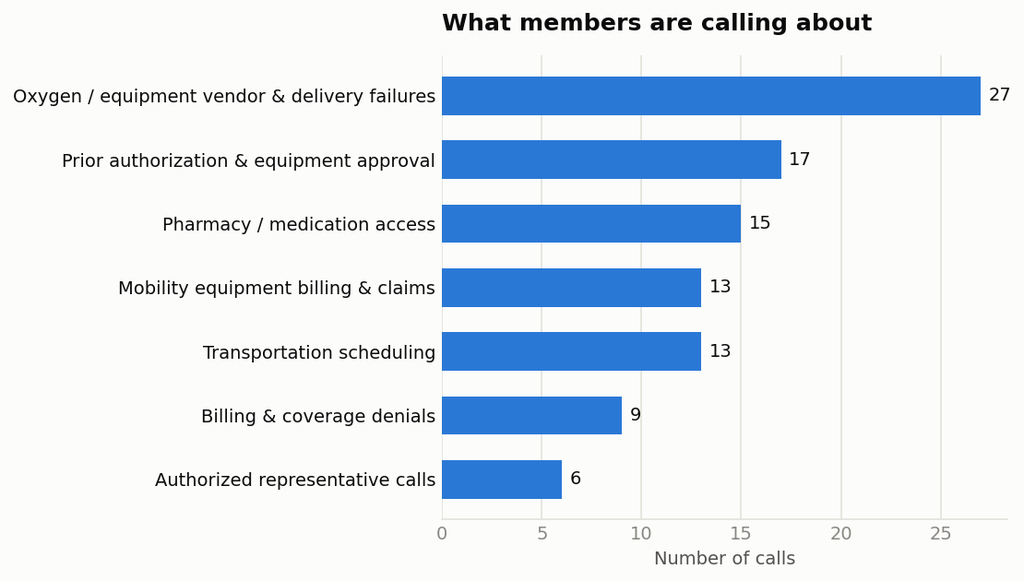

```python
# Chart 1: call volume by theme
counts = theme_counts.sort_values()

fig, ax = plt.subplots(figsize=(8, 4.6), dpi=140)
bars = ax.barh(counts.index, counts.values, color=BLUE, height=0.6)
clean_axes(ax)
ax.set_xlabel("Number of calls")
ax.set_title("What members are calling about", loc="left", fontsize=13, fontweight="bold", pad=14)
ax.grid(axis="x", color=GRID, linewidth=0.8)

for bar, val in zip(bars, counts.values):
    ax.text(bar.get_width() + 0.4, bar.get_y() + bar.get_height() / 2, str(val), va="center", fontsize=10)

plt.tight_layout()
plt.show()
```

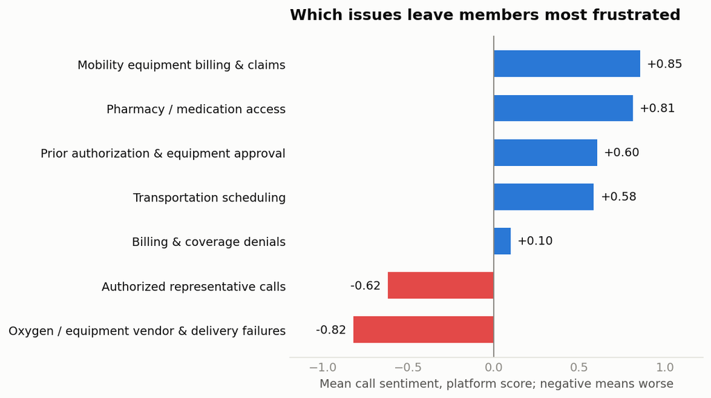

```python
# Chart 2: sentiment by theme. Red bars are negative, blue bars are positive.
s = df.groupby("theme_label")[sent_col].mean().sort_values()
colors = [RED if v < 0 else BLUE for v in s.values]

fig, ax = plt.subplots(figsize=(8.5, 4.8), dpi=140)
bars = ax.barh(s.index, s.values, color=colors, height=0.6)
clean_axes(ax)
ax.axvline(0, color=MUTED, linewidth=1)
ax.set_xlabel("Mean call sentiment, platform score; negative means worse")
ax.set_title("Which issues leave members most frustrated", loc="left", fontsize=13, fontweight="bold", pad=14)

lo, hi = s.min(), s.max()
pad = (hi - lo) * 0.22
ax.set_xlim(lo - pad, hi + pad)

for bar, val in zip(bars, s.values):
    ha = "left" if val >= 0 else "right"
    off = 0.04 if val >= 0 else -0.04
    ax.text(bar.get_width() + off, bar.get_y() + bar.get_height() / 2, f"{val:+.2f}", va="center", ha=ha, fontsize=10)

plt.tight_layout()
plt.show()
```

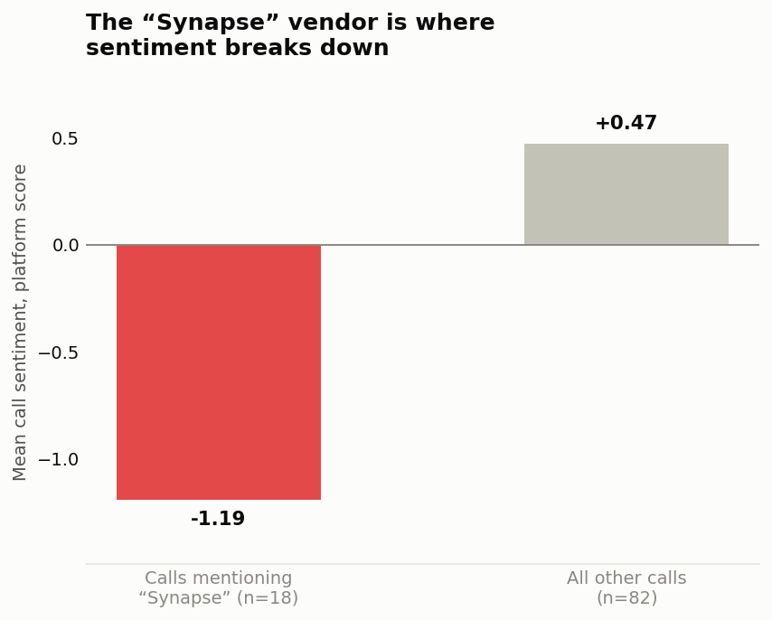

```python
# Chart 3: Synapse calls compared with everyone else
labels = [f"Calls mentioning\n“Synapse” (n={mentions_synapse.sum()})", f"All other calls\n(n={(~mentions_synapse).sum()})"]
vals = [syn_mean, other_mean]

fig, ax = plt.subplots(figsize=(6.2, 5.0), dpi=140)
bars = ax.bar(labels, vals, color=[RED, GRAY_MID], width=0.5)
clean_axes(ax)
ax.axhline(0, color=MUTED, linewidth=1)
ax.set_ylabel("Mean call sentiment, platform score")
ax.set_title("The “Synapse” vendor is where\nsentiment breaks down", loc="left", fontsize=13, fontweight="bold", pad=14)

lo_, hi_ = min(vals + [0]), max(vals + [0])
span = hi_ - lo_
ax.set_ylim(lo_ - span * 0.18, hi_ + span * 0.18)

for bar, val in zip(bars, vals):
    va = "bottom" if val >= 0 else "top"
    off = span * 0.03 if val >= 0 else -span * 0.03
    ax.text(bar.get_x() + bar.get_width() / 2, val + off, f"{val:+.2f}", ha="center", va=va, fontsize=11, fontweight="bold")

plt.tight_layout()
plt.show()
```

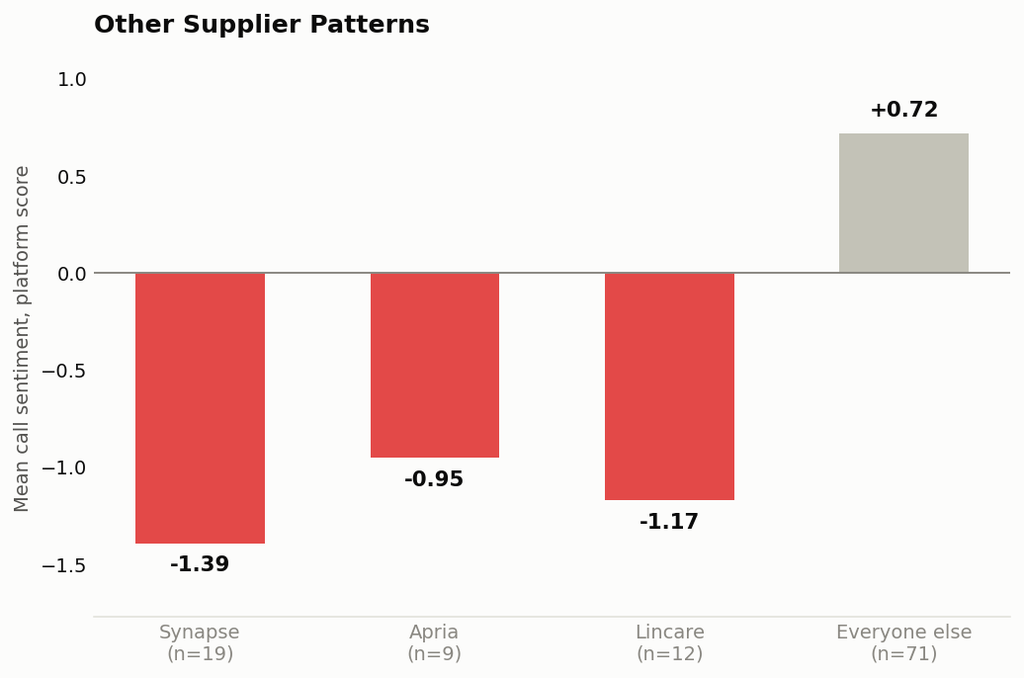

```python
# Chart 4: Synapse compared with the other two named suppliers, and everyone else
labels = [f"{name.split(' (')[0]}\n(n={mask.sum()})" for name, mask in vendor_masks.items()]
labels.append(f"Everyone else\n(n={(~any_named_vendor).sum()})")
vals = list(vendor_checks["mean Call Sent, matched"]) + [round(df.loc[~any_named_vendor, sent_col].mean(), 2)]

fig, ax = plt.subplots(figsize=(7.5, 5.0), dpi=140)
bars = ax.bar(labels, vals, color=[RED, RED, RED, GRAY_MID], width=0.55)
clean_axes(ax)
ax.axhline(0, color=MUTED, linewidth=1)
ax.set_ylabel("Mean call sentiment, platform score")
ax.set_title("Other Supplier Patterns", loc="left", fontsize=13, fontweight="bold", pad=14)

lo_, hi_ = min(vals + [0]), max(vals + [0])
span = hi_ - lo_
ax.set_ylim(lo_ - span * 0.18, hi_ + span * 0.18)

for bar, val in zip(bars, vals):
    va = "bottom" if val >= 0 else "top"
    off = span * 0.03 if val >= 0 else -span * 0.03
    ax.text(bar.get_x() + bar.get_width() / 2, val + off, f"{val:+.2f}", ha="center", va=va, fontsize=11, fontweight="bold")

plt.tight_layout()
plt.show()
```

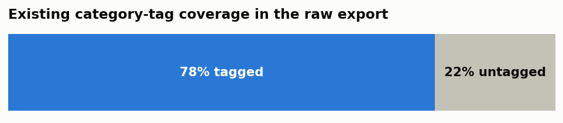

```python
# Chart 5: how much of the raw export actually has a usable category tag
fig, ax = plt.subplots(figsize=(7, 1.6), dpi=140)
ax.barh([0], [n_tagged], color=BLUE, height=0.5)
ax.barh([0], [n_untagged], left=[n_tagged], color=GRAY_MID, height=0.5)
ax.set_xlim(0, n_tagged + n_untagged)
ax.set_yticks([]); ax.set_xticks([])
for s in ax.spines.values():
    s.set_visible(False)

pct = n_tagged / (n_tagged + n_untagged) * 100
ax.text(n_tagged / 2, 0, f"{pct:.0f}% tagged", ha="center", va="center", color="white", fontsize=11, fontweight="bold")
ax.text(n_tagged + n_untagged / 2, 0, f"{100-pct:.0f}% untagged", ha="center", va="center", fontsize=11, fontweight="bold")
ax.set_title("Existing category-tag coverage in the raw export", loc="left", fontsize=12, fontweight="bold", pad=10)

plt.tight_layout()
plt.show()
```

## 9. Summary and recommendations

**Data quality:** 2 summary-only rows were flagged. Personal information was found unredacted in 11 transcripts and redacted before the model touched it. 22% of calls have no usable category tag, a gap large enough that it hid this report's main finding from standard reporting. The full manual-review file is described in Section 3.

**Themes members are calling about:** independent of the platform's own tags: equipment issues, including oxygen, prior authorization, and mobility equipment billing, make up the majority of call volume, followed by pharmacy and medication access, then transportation scheduling.

**What I would recommend:**

1. Look into the Synapse vendor relationship directly. It is the clearest, statistically-supported driver of negative member experience in this sample, though as shown in Section 7, Apria and Lincare follow a similar pattern, so the review is probably better framed around the DME supplier relationship broadly rather than Synapse alone.
2. Close the category-tagging gap, currently 22% untagged, so that patterns like this one do not stay hidden from routine reporting in the future.
3. Audit the personal-information redaction step in the transcript export pipeline itself, since it should not be reaching this stage unredacted.
4. **Automation opportunity:** Use the frustration score from Section 6 to route the worst-scoring calls to quality review, not only as a one-time statistic in this analysis.